# FigureYa14 Circos

小丫画图出品

6/24/2018

微信ID: epigenomics E-mail: epigenomics@rainbow-genome.com

配置文件的作者：Zhaodong Hao E-mail: haozd1992@163.com

Circos用法由小丫编译

### 需求描述

用Circos画出paper里的圆圈图，包括GC含量、gene密度、RPKM、SNP等。

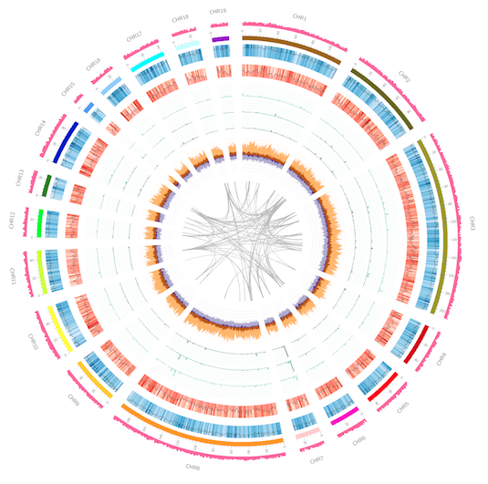

如果要画直的染色体，请购买代码10

### 应用场景

**场景一**：展示基因组上多条染色体、单条染色体、或多个基因上的特征。

**场景二**：展示不同细胞类型或人群的特征。

**特征包括但不限于**：GC含量差异、基因密度差异、基因表达量、染色质开放程度、DNA甲基化、SNP等等。

### 运行环境的准备

#### 1. 安装perl

Circos是用perl写成的，在装有perl的任何操作系统上都可以运行。

Mac和Linux系统自带perl；Windows系统需要到http://downloads.activestate.com/ActivePerl/releases/下载安装ActivePerl。

**注意**：在终端（Terminal）运行Circos，不需要R。

#### 2. 安装Circos

到http://circos.ca/software/download/circos/下载circos-0.69-6.tgz，解压缩到哪里就相当于安装到哪个文件夹了。

#### 3. 安装perl模块（module）

先在终端（Terminal）输入下面的命令

```r
./bin/circos -modules
```

运行结果像这样：

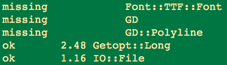

**ok**：电脑上已经有了哪些模块

**missing**：需要安装哪些模块

然后在终端输入下面的命令，进入cpan

```r
sudo cpan
```

安装完，在键盘上按下`q`，就退出了cpan

##### GD模块的安装方法

用上面的方法安装GD模块会失败。有人已经把安装GD所需的模块打包在一起，文件来源：http://www.zxzyl.com/archives/712，下载链接http://p7dameffm.bkt.clouddn.com/wp/FileAttach/2015-05-08-install-gd.tar.gz

解压缩`2015-05-08-install-gd.tar.gz`

在终端运行以下命令，就安装好了gd：

```r
cd gd
sudo ./install
```

来到circos-0.69-6的目录下，在终端（Terminal）输入下面的命令，检查一下是不是都是`ok`了

```r
/bin/circos -modules
```

#### 4. 测试

进入circos-0.69-6/example目录，用测试数据做正对照，看看能否跑出图

```r
cd circos-0.69-6/example
../bin/circos -conf etc/circos.conf
```

会产生circos.svg和circos.png两个文件。

打开circos.png，欣赏Circos的强大。

### 最短的时间画出自己的图

现在你已经装好了系统，只要按照以下四步操作，就可以直接跳到“开始画图”部分，用自己的数据画出文档开头那样的图：

1. 去circos-0.69-6/data/karyotype目录找你需要的物种，记住文件名；
2. 把Mydata文件夹放到circos-0.69-6主目录下，然后把Mydata/etc/circos.conf文件中的`karyotype.species.txt`改成你需要的物种的文件名；
3. 打开circos-0.69-6/Mydata/etc/data/文件夹，挑你感兴趣的数据类型，看懂格式，用你自己的数据替换原有的数据。
4. 把circos-0.69-6/Mydata/etc/circos.conf文件中你不需要的数据对应的段落删掉。

```r
## track for GC content  #这是段落的开头
<plot>
show   = conf(show_lines)
type   = line
file   = data/GC_content.txt

thickness = 1
color   = 247,104,161
min    = 32
max    = 43
r0     = 1.05r
r1     = 1.08r
fill_color = 247,104,161
</plot>  #这是段落的结尾
```

下面开始按部就班的讲解各个文件是干啥用的，懒人可跳过，直接进入“开始画图”。

### 需要准备的文件

需要三种文件：karyotype、配置文件和输入数据。

#### karyotype

circos-0.69-6/data/karyotype目录下已经有很多物种的karyotype文件。

你也可以自己写karyotype文件，例如karyotype.species.txt，把它放到circos-0.69-6/data/karyotype目录下。

```r
chr - Chr1 CHR1 0 118073833 chr1
chr - Chr2 CHR2 0 98364873 chr2
chr - Chr3 CHR3 0 207093695 chr3
chr - Chr4 CHR4 0 50051714 chr4
chr - Chr5 CHR5 0 45443526 chr5
chr - Chr6 CHR6 0 35772468 chr6
chr - Chr7 CHR7 0 28624509 chr7
chr - Chr8 CHR8 0 195669025 chr8
chr - Chr9 CHR9 0 55551413 chr9
```

#### 配置文件

配置文件，也就是画图的参数，保存在circos-0.69-6/Mydata/etc/下面的*.conf文件中，其中circos.conf是必需的。

整个图里的信息，例如圈要画多大、颜色、哪里有连线、哪里画曲线、哪里画柱形图、以及调用哪个文件里的数据，全靠conf文件来告诉Circos。

复杂的图参数也多，于是，就把参数分门别类的保存在多个配置文件中。在circos.conf文件里统一通过`include + conf文件名`来调用其余的conf文件，因此其余conf的文件名在circos.conf文件中都能找到。

##### 注意

你会发现：有些include后面跟了当前文件夹里不存在的conf文件。

```r
<<include etc/image.conf>>
<<include etc/colors_fonts_patterns.conf>>
<<include etc/housekeeping.conf>>
```

这些是保存在circos-0.69-6/etc下面的配置文件，是必须导入的。

circos-0.69-6/etc下面的配置文件我们都不要改动。

我们自己写的文件只保存在Mydata下面，随便你怎么改。

#### 读懂配置文件

Circos网站的tutorial教程很好用，http://circos.ca/documentation/tutorials/quick_start/，下面三个例子让你用3分钟get到配置文件怎么看：

##### 例子一：QUICK START中的1.Hellow World

点开看：http://circos.ca/documentation/tutorials/quick_start/hello_world/configuration

CIRCOS.CONF负责告诉Circos，染色体要画多大（半径radius）、多粗（thickness）等等。

只靠karyotype.human.txt和一个简单的配置文件CIRCOS.CONF，就画出了这样的一圈染色体：

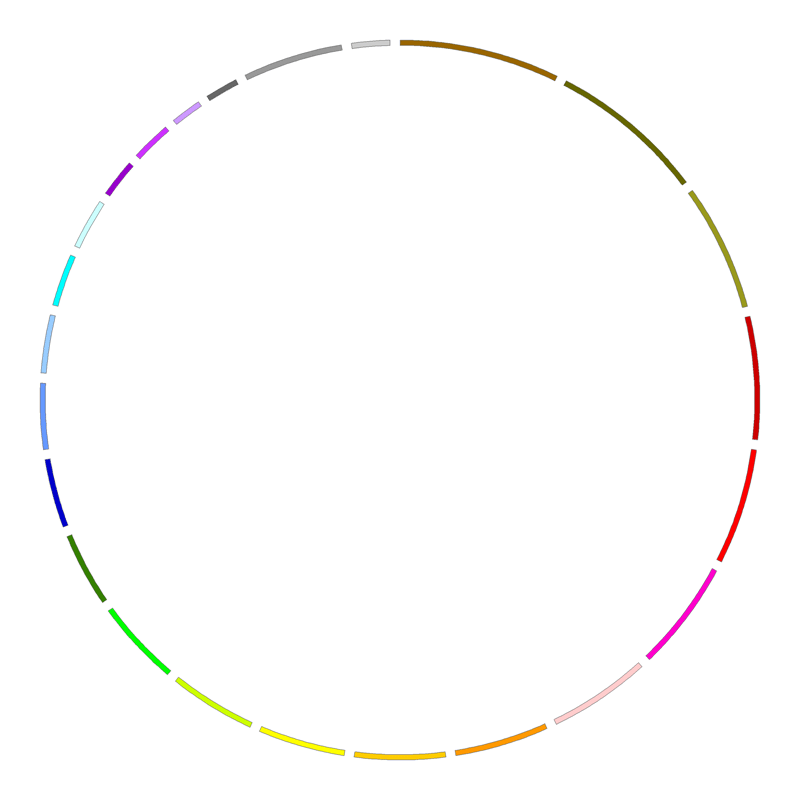

##### 例子二：QUICK START中的2.Ticks And Lables

点开看：http://circos.ca/documentation/tutorials/quick_start/ticks_and_labels/configuration

在segment（此处是染色体）上添加刻度和lable（标签，此处是染色体名），写在3个配置文件里：CIRCOS.CONF、IDEOGRAM.CONF（染色体和标签）、TICKS.CONF（刻度）。就画出了这样的一圈带刻度和标签的染色体：

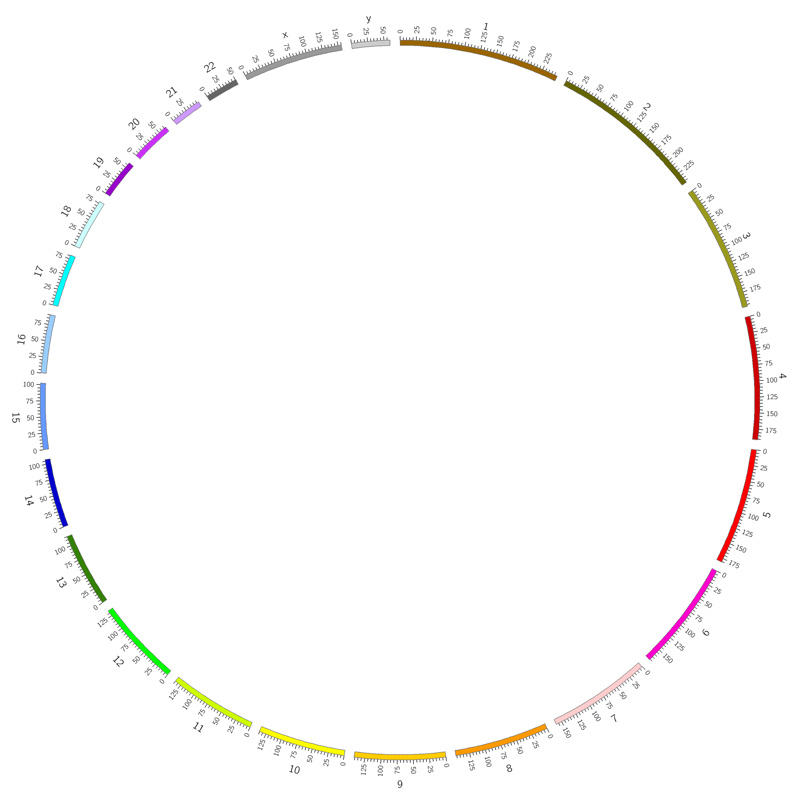

##### 例子三：菜谱中的CELL CYCLE — PART 1

Circos网站给出了很多现成的菜谱，http://circos.ca/documentation/tutorials/recipes/

Configuration里面都是搭配好的conf文件，复制粘贴到记事本里，保存成.conf为扩展名的文件。用户只要提供自己的数据（见后面的“输入数据”部分），就可以画出像菜谱中那样的图了。

点开看http://circos.ca/documentation/tutorials/recipes/cell_cycle_part_1/configuration

这个图复杂，配置文件也多：CIRCOS.CONF、IDEOGRAM.CONF、IDEOGRAM.LABEL.CONF、IDEOGRAM.POSITION.CONF、TICKS.CONF

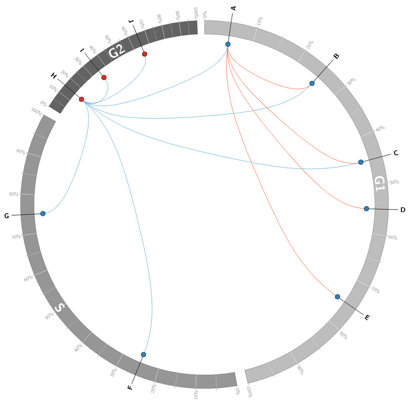

### 最实用的配置文件，自己paper里能用到

本文档开头秀出的图就是用circos-0.69-6/Mydata/etc/文件夹里的三个conf画出的。

可以用文本编辑器（例如Notepad++）查看、编辑。

**包括3个配置文件：**

ideogram.conf，染色体想画成什么样

ticks.conf，染色体上的刻度和标签

circos.conf，我的输入数据文件以及另外两个配置文件都挂在这个circos.conf文件里，因此，后面画图时，只需要告诉Circos，circos.conf在哪里。

circos.conf的开头就定义好了这个圈里要画哪几种类型的图：

```r
show_links      = yes
show_heatmaps   = yes
show_lines      = yes
show_histograms = yes
```

然后告诉Circos，karyotype文件在哪里，用哪个。

接下来就是各个输入数据在圈上要展示成什么样子的具体参数，重点看`#`后面的注释，标出了重要参数的解释。

### 输入数据

要在圈上展示的数据都保存到circos-0.69-6/Mydata/data文件夹下，想画几个圈就存几个文件。

Mydata文件夹放在Circos主目录下，跟circos-0.69-6/Mydata/etc/文件夹里的三个conf、以及karyotype.species.txt文件是一套的。

第一列是片段（segment）ID，此处是染色体；

第二列和第三列是片段上的起止位置，此处是碱基的位置；

第四列是信号值，例如GC含量、基因表达量RPKM等。

```r
Chr1    0   999999  39.07
Chr1    1000000 1999999 36.13
Chr1    2000000 2999999 38.18
Chr1    3000000 3999999 39.49
Chr1    4000000 4999999 37.42
Chr1    5000000 5999999 36.98
Chr1    6000000 6999999 38.2
Chr1    7000000 7999999 38.65
Chr1    8000000 8999999 39.18
Chr1    9000000 9999999 37.54
```

### 开始画图

输入数据文件以及其他配置文件都挂在circos-0.69-6/Mydata/etc/circos.conf文件里，因此画图时，只需要告诉Circos，circos.conf在哪里。

在终端里，进入Mydata目录，输入命令：

```r
../bin/circos -conf etc/circos.conf
```

会在当前文件夹产生circos.svg和circos.png两个文件。

circos.svg是矢量图，可以用illustrator或inkscape打开、编辑、保存成pdf等文件。

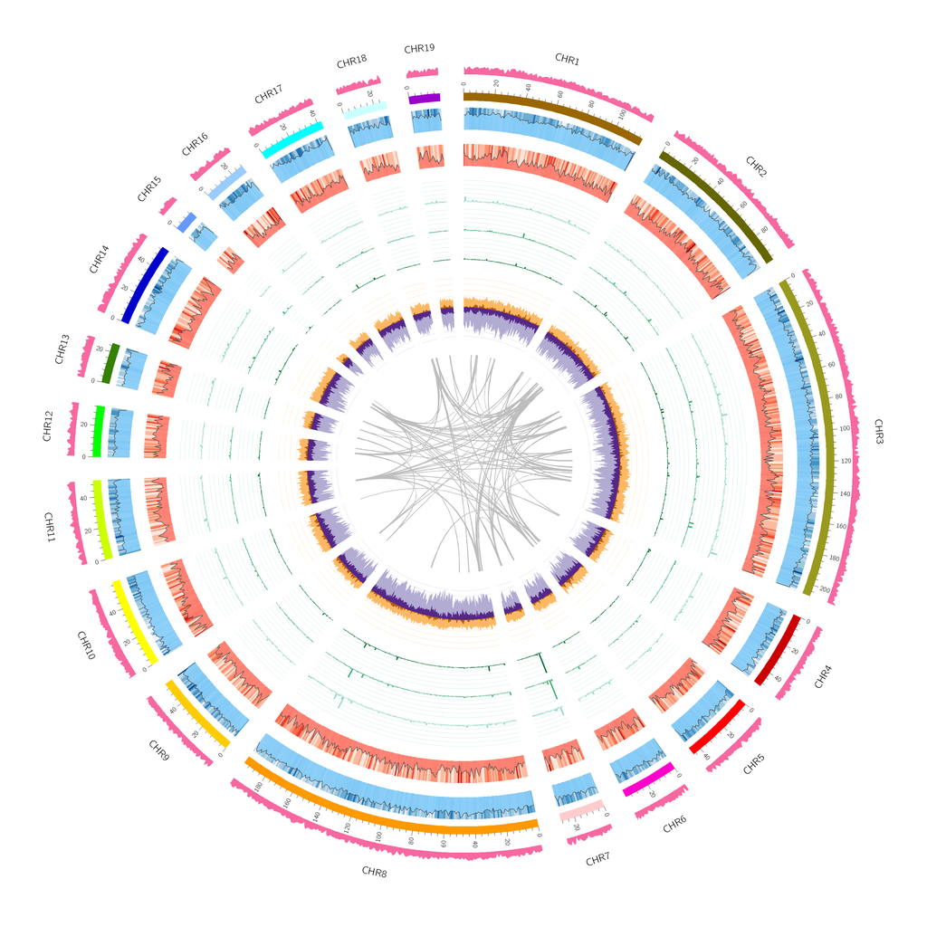

##### Figure legend通用格式

**Figure 1 **(species name) genome overview.** (a) GC content (30.86-40.82 per Mb). (b) Pseudomolecules of **. (c) TEs content (42.38-75.59% per Mb for heatmap) and TEs number (128-3266 per Mb for line). (d) Gene content (0-41.23% per Mb for heatmap) and gene number (0-53 per Mb for line). (e) Average expression state (reads per kilobase of exon per million sequences mapped, RPKM) for RKAM_3 (-0.19-2.48 per gene per Mb). (f) Average expression state for RKAM_2 (-0.11-4.06 per gene per Mb). (g) Average expression state for RKAM_1 (-0.08-4.22 per gene per Mb). (h) Heterozygous and homozygous SNPs identified by resequencing the sample_2. (i) Heterozygous and homozygous SNPs identified by resequencing the sample_1. (j) Synthetic blocks.

### 画非染色体

读懂了上面画染色体的配置文件和输入数据，就可以灵活运用Circos画各种各样的图了。

无非是把karyotype和chromosome换成segment set和segment来理解，segment可以是染色体，也可以是基因、一种细胞系、一个人群。